# Module 8: U.S. Equity Market Structure

STAT 4170 – Financial Time Series and Forecasting

Taylor R. Brown

# Part 1: Why These Tools, for CS 3

## Recap: What We Built in Module 7

Two random ingredients drive the market maker’s problem:

1. **When do orders arrive?** — a **Poisson process**, $N(t)$
2. **How does the fair price move?** — **Brownian motion**, $W(t)$

We also saw, with real SPY data, that both idealizations are imperfect: order flow is bursty and time-varying, and price moves continuously but jaggedly. Still, they’re the right *starting point* — tractable models we now extend into a full market-making analysis.

## What’s Still Missing

Module 7 treated “an order arrives” as a black box. It isn’t one: *where* do orders actually get routed, matched, and priced? Real order flow is shaped by exchange rules, rebates, and routing incentives, not just an arrival rate $\lambda$.

Today fills in that institutional plumbing — the market microstructure CS 3 assumes you understand.

# Part 2: US Equities Market Infrastructure

## Why Isn’t There Just “The Stock Market”?

There is no single place SPY trades. U.S. equity trading is **fragmented and competing** by design: in 1975 Congress directed the SEC to build a national market system that assures “fair competition among brokers and dealers, among exchange markets, and between exchange markets and markets other than exchange markets” (Securities Exchange Act §11A(a)(1)(C)(ii), 15 U.S.C. §78k-1). Competition among many linked venues is the mandate; fragmentation is what it looks like in practice.

- **16 registered national securities exchanges** (NYSE, Nasdaq, Cboe’s four venues, IEX, MEMX, MIAX Pearl, LTSE, …), plus dozens of **Alternative Trading Systems (ATSs)** — most of which are “dark pools” (related, but not synonyms — see two slides ahead)
- **Regulation NMS** (2005) requires that a trade execute at the **best displayed price available anywhere** (the Order Protection Rule) — no exchange can trade through a better price posted on a competitor
- Result: exchanges must be electronically linked and constantly race each other on price, speed, and fees to attract order flow

This is the environment CS 3’s market maker operates in — not one order book, but a network of competing, interlinked ones.

## Real Data: How Fragmented Is SPY Trading, Really?

`data/20260812_spy.txt` — the same file from Module 7 — tags every trade print with the venue that reported it. Let’s look at the actual mix for one day of SPY:

```python
import numpy as np
import pandas as pd
import matplotlib.pyplot as plt

exchanges = []
with open("../../data/20260812_spy.txt") as f:
    for line in f:
        if "last=" not in line:
            continue
        i = line.index("exchange=") + 9
        j = line.index(",", i)
        exchanges.append(line[i:j])

counts = pd.Series(exchanges).value_counts()
print(counts)

fig, ax = plt.subplots(figsize=(10, 5))
counts.plot(kind="bar", ax=ax, color="C0")
ax.set_ylabel("trade prints, 2026-08-12")
ax.set_title("SPY trade prints by reporting venue")
plt.tight_layout()
plt.show()
```

Real trades in a single, heavily-traded ETF, printed across a dozen-plus distinct venues in one day. `UNKNOWN` and `DARK` are trades that never touched a lit exchange book at all — more on that shortly.

## Real Data: How Fragmented Is SPY Trading, Really?

```
DARK        232220
NASDAQ       69914
ARCA         63664
BATS         30878
DRCTEDGE     18795
IEX          17246
NYSE         16276
MEMX          9714
BYX           3219
EDGEA         2832
PEARL         2062
PSX           1635
UNKNOWN        955
BEX            871
AMEX           731
NYSENAT        253
Name: count, dtype: int64
```

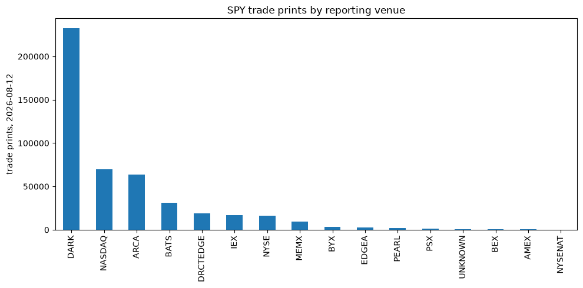

## Lit Exchanges vs. Dark Pools

- **Lit exchanges** (NYSE, Nasdaq, Cboe BZX/BYX/EDGX/EDGA, IEX, MEMX, MIAX Pearl, …) post **public, displayed** bid/ask quotes. These quotes are what combine to form the **NBBO** (National Best Bid and Offer).
- **ATS vs. dark pool — not quite the same thing.** An **ATS** is a *regulatory category*: a venue that matches buyers and sellers but is registered as a broker-dealer under Regulation ATS rather than as an exchange. A **dark pool** is an ATS that **doesn’t display quotes**. Nearly every equity ATS today is dark, which is why the terms get used interchangeably — but an ATS can be lit (the ECNs of the 1990s–2000s, such as Island and Archipelago, were ATSs with displayed books).
- **Wholesalers / internalizers** (Citadel Securities, Virtu, …) are a third thing: also off-exchange and undisplayed, but they are dealers filling orders against their own inventory, not ATSs — and they handle more off-exchange volume than the dark pools do.
- All of these trade **without displaying a quote**. A trade happens, then gets reported after the fact to a **FINRA Trade Reporting Facility (TRF)** — this is the `DARK` tag in the data above, which lumps dark-pool and wholesaler prints together.
- Roughly **40–50% of U.S. equity volume** trades off-exchange in a given period. Dark venues exist because large or informed traders don’t want to reveal size and intent by resting a visible order.

For a market maker quoting on a lit exchange, this matters: displayed liquidity is only part of the picture, and a meaningful share of flow never has a chance to interact with your quote at all.

## Price-Time Priority: How a Limit Order Book Matches Trades

Within a single exchange’s order book, resting orders are ranked by two rules, applied in order:

1. **Price priority** — better prices trade first (higher bids, lower asks)
2. **Time priority** — among orders at the *same* price, first-in-first-out (FIFO) by arrival time

Implication: two market makers quoting the *identical* price are not equally likely to get filled. The one who arrived first is at the front of the queue and gets executed first. This is why speed and queue position — not just where you quote — determine realized fill rates, and why the fill-rate functions $\lambda_{\text{buy}}(\cdot), \lambda_{\text{sell}}(\cdot)$ we’ll keep using implicitly bake in “you got to the front of the queue.”

## Exceptions to Price-Time Priority

Price-time is the default for U.S. stocks, but it is a design choice, and some venues choose differently:

**Price-size (pro-rata) priority.** Price still comes first, but orders at the *same* price share an incoming trade **in proportion to their size** instead of first-come-first-served. If you rest 800 shares and a competitor rests 200 at the same price, an incoming 100-share order gives you 80 and them 20, no matter who arrived first. The race is to post *size*, not to arrive early.

- **Options exchanges** are where this is common: Cboe Options, Nasdaq PHLX, Nasdaq ISE, NYSE American Options, and MIAX Options all allocate pro rata (usually with customer orders first in line).
- **Futures:** CME uses pro-rata-style allocation for some short-term interest rate contracts.
- **Stocks:** Nasdaq PSX launched in 2010 as a price-size equity exchange, and ran pro-rata variants on and off until 2019. Today every U.S. stock exchange is price-time (NYSE’s “parity” allocation among floor participants is the closest thing to an exception).

**Speed bumps.** IEX deliberately adds a 350-microsecond “speed bump” to every incoming order, specifically to blunt the advantage of the fastest participants. It keeps price-time ordering but makes being *slightly* faster worth less.

Both are deliberate designs, not accidents — evidence that queue position and speed are seen as a real economic advantage worth designing (and regulating) around.

## Market Data Feeds: How Much of the Book Can You See?

Price-time priority only matters to you insofar as your data lets you *observe* it. Exchanges and resellers sell several tiers of market data, each revealing progressively more of the book — and costing progressively more:

| Feed | Also called | What it shows |
| --- | --- | --- |
| **Level 1** | Top of book | Best bid/ask price and size (the NBBO), plus last trade — nothing behind the touch |
| **Level 2** | Market by price (MBP) | Every resting price level and the *aggregated* size at each, but not the individual orders behind it |
| **Level 3** | Market by order (MBO) | The full order book: every individual resting order, its size, and its exact queue position at each price level |

**MBO is order-level, not identity-level.** On U.S. equity feeds each resting order shows up with an anonymous order ID — you see *that* there are five separate orders ahead of you and how big each is, but not *who* sent them. (You can find your own, because you know your own order IDs.) Attribution is the exception: Nasdaq lets a firm opt in to showing its market participant ID on an order, and some non-U.S. markets publish broker codes, but anonymity is the norm.

Only **MBO/Level 3** actually lets you observe time priority directly — it’s the sole feed where “who’s first in the queue at this price” is a visible fact rather than an inference. It’s also the most expensive and highest-bandwidth product on the market, for the same reason direct feeds beat the SIP: more (and faster) information costs money.

**Where our data sits:** the SPY file we’ve been using all module (`bid=`, `ask=`, `bid_size=`, `ask_size=`, `last=`) is **Level 1** — top-of-book only. We can see *that* the touch has 320 shares bid, but not how many separate orders make up those 320 shares, or in what order they’ll fill. That’s a real limitation worth remembering when building CS 3’s simulator: the fill-rate functions $\lambda_{\text{buy}}(\cdot), \lambda_{\text{sell}}(\cdot)$ have to *model* queue-position effects that MBO data would let you observe directly.

## Maker-Taker: The Rebate Model

Exchanges don’t just match orders — they charge for the privilege, and the pricing is asymmetric:

- **Takers** (orders that execute immediately against a resting quote — think market orders; “aggressive” orders) pay a **fee**, e.g. roughly $0.0030/share
- **Makers** (resting limit orders that get executed against — “liquidity providers”) earn a **rebate**, e.g. roughly $0.0020–0.0028/share

This is the **maker-taker model**, and it’s why posting passive quotes is attractive beyond just capturing the spread. Some venues **invert** this (pay the taker, charge the maker) to attract a different mix of order flow.

**For CS 3:** a market maker’s realized economics are

$$\text{edge} = \text{captured spread} + \text{rebates} - \text{fees} - \text{adverse selection cost}$$

not just the quoted half-spread $\delta$ from the model — rebates are real, per-share revenue on every passive fill.

## What Makes Order Flow “Toxic”?

A liquidity provider’s real enemy isn’t the bid-ask spread being too thin — it’s **adverse selection**: getting picked off by a counterparty who knows (or can predict) that the price is about to move against the position you just took on.

- **Toxic flow**: trades that tend to be followed by an adverse price move for whoever provided liquidity. If you’re consistently long *right before* the price drops, or short *right before* it rises, the flow you’re filling is toxic — someone on the other side had an edge.
- **Uninformed / benign flow**: trades uncorrelated with the price’s next move. Filling these is close to “free money” — you collect the spread with no systematic loss afterward.
- This is exactly the **adverse selection cost** term in the edge equation above: it’s the average post-trade price drift, signed against the liquidity provider, weighted by how often it happens.

Why retail flow is prized: a retail investor buying 10 shares of SPY for a brokerage account is very unlikely to be acting on short-lived information that moves the price against the fill a moment later. An institutional order working a large position, or a fast proprietary trading firm’s order, is far more likely to be — so wholesalers and market makers price (and compete for) flow differently based on how toxic it tends to be.

## Decomposing a Limit Order’s Expected Value: Setup

Rest a limit **sell** for one share at price $P_a$, above the best ask.

- $P_t$ is the true fair value, with $P_0 < P_a$ when we place the order
- $\tau$ is the (random) time we get filled; $T$ is the time we cancel if still unfilled
- Marked at fair value at time $T$, the order earns $(P_a - P_T)\,\mathbf{1}\{\tau \le T\}$ — nothing if it never fills

**Assumption:** fair value is a **martingale** — $E[P_t \mid \mathcal{F}_s] = P_s$ for $s \le t$, where $\mathcal{F}_s$ is everything known at time $s$, including our own fills. No predictable drift. (Module 9 makes this precise.)

**Tool:** the **optional stopping theorem**. Two consequences we’ll use:

$$\underbrace{E[P_T \mid \mathcal{F}_\tau] = P_\tau \ \text{ on } \{\tau \le T\}}_{\sigma = \tau,\ \rho = T}, \qquad \underbrace{E[P_{\tau \wedge T}] = P_0}_{\sigma = 0,\ \rho = \tau \wedge T}$$

## Decomposing a Limit Order’s Expected Value: The Math

$$\begin{aligned}
E\big[(P_a - P_T)\,\mathbf{1}\{\tau \le T\}\big]
&= E\Big[\,E\big[(P_a - P_T)\,\mathbf{1}\{\tau \le T\} \,\big|\, \mathcal{F}_\tau\big]\Big]
&& \text{iterated expectations: condition on the fill time} \\
&= E\Big[\mathbf{1}\{\tau \le T\}\,\big(P_a - E[P_T \mid \mathcal{F}_\tau]\big)\Big]
&& P_a \text{ and } \mathbf{1}\{\tau \le T\} \text{ are known at } \tau \\
&= E\big[\mathbf{1}\{\tau \le T\}\,(P_a - P_\tau)\big]
&& \text{optional stopping theorem (two-stopping-time form; beyond our scope today)} \\
&= P(\tau \le T)\,\big(P_a - E[P_\tau \mid \tau \le T]\big)
&& \text{iterated expectations: condition on being filled} \\
&= \underbrace{P(\tau \le T)}_{\text{fill probability}} \times \Big[\,\underbrace{(P_a - P_0)}_{\text{quoted edge}} - \underbrace{\big(E[P_\tau \mid \tau \le T] - P_0\big)}_{\text{adverse selection}}\,\Big]
&& \text{add and subtract } P_0
\end{aligned}$$

- **Quoted edge vs. fill probability** is the trade-off behind the half-spread $\delta$: quote farther from fair value and you earn more per fill, but fill less often.
- **Adverse selection** is how far fair value has already moved *toward your price* by the instant you’re filled. It is selection, not drift: since $E[P_{\tau \wedge T}] = P_0$, the paths where you fill are the ones where fair value rose, offset by the unfilled paths where it fell.
- **Worst case:** if you only ever fill when fair value itself has reached $P_a$, then $P_\tau = P_a$ and the expected value is **zero**, however wide you quote. Profit requires someone to pay $P_a$ while fair value is still below it — benign flow, which is why it’s worth paying for.

Add the rebate inside the bracket and this is the per-share edge equation from the maker-taker slide, with each term now defined.

## Payment for Order Flow (PFOF)

Retail brokers (Robinhood, Schwab, …) mostly do **not** send your market order to a lit exchange. Instead:

1. The broker routes your order to a **wholesaler** — a market-making firm like Citadel Securities, Virtu, or Susquehanna
2. The wholesaler pays the broker for that order flow (this payment is the **PFOF**)
3. The wholesaler typically **internalizes** the trade — fills it directly, often with a small amount of price improvement over the NBBO, rather than routing to an exchange at all

Why is retail flow worth paying for? Per the previous slide, it’s about as **non-toxic** as order flow gets — low adverse selection means the wholesaler can internalize it profitably and still offer the retail trader a bit of price improvement.

## Getting One Consolidated Price: The SIP

With 16+ lit venues each publishing their own quotes, who computes the single “best bid and offer” you see on a screen or news ticker?

- The **SIP** (Securities Information Processor) collects quotes from every lit exchange and disseminates the **consolidated NBBO**
- There are actually two SIPs, each run under a joint plan of the exchanges and FINRA that the SEC oversees:
  - the **CTA** plans ([Consolidated Tape Association](https://www.ctaplan.com), with its companion Consolidated Quotation plan) cover stocks listed on NYSE and on other non-Nasdaq exchanges — “Tape A” and “Tape B”. SPY is listed on NYSE Arca, so it is a Tape B security
  - the **UTP** plan ([Unlisted Trading Privileges](https://www.utpplan.com) — the right of one exchange to trade a stock listed on another) covers Nasdaq-listed stocks — “Tape C”
- The catch: the SIP has always run **slower** than each exchange’s own **direct proprietary feed**. Direct feeds are faster (and cost extra) precisely because firms are willing to pay for a head start
- Even after the 2020s SIP modernization narrowed this considerably, a firm paying for colocated direct feeds still sees exchange-level price changes measurably before the consolidated SIP tape updates

This latency gap is the source of the “latency arbitrage” critique of HFT: a fast firm with direct feeds can, in principle, trade against a slower participant who is still looking at a now-stale SIP-based NBBO.

## Two Books, One Stock: When Is It an Arbitrage?

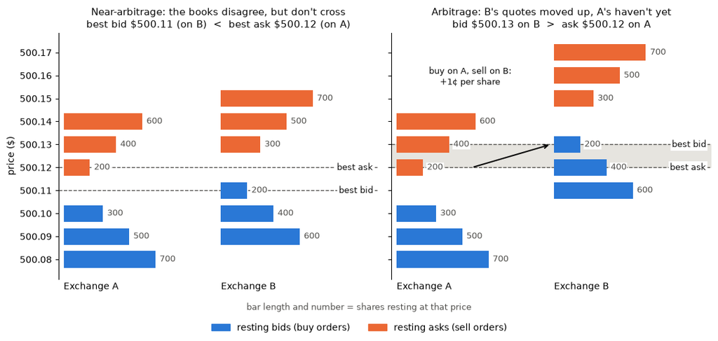

**Left:** the two venues quote slightly different prices, but every bid is still below every ask — there is nothing to lock in. Together they form the NBBO: $500.11 bid (from B) × $500.12 offered (from A). **Right:** the market is *crossed* — B is bidding more than A is asking — so buying on A and selling on B at the same instant earns 1¢ a share, up to the 200 shares available on each side, before fees.

## Anchoring the Time Scales

Everything above happens at wildly different clock speeds. Rough orders of magnitude:

| Event | Typical timescale |
| --- | --- |
| Light in a vacuum travels about 0.3 meters (1 foot) | 1 **nanosecond** |
| One CPU clock cycle at 3 GHz — enough for a few simple instructions, like adding two integers | ~0.3 nanoseconds |
| Signal down 100 m of Cat 6 copper Ethernet cable (the longest standard run), at about ⅔ the speed of light | ~0.5 **microseconds** |
| SIP consolidated NBBO update latency | hundreds of microseconds to low **milliseconds** |
| Light in a vacuum, one-way, NY-area to Chicago (~700 miles) — the **physical floor**, not achievable in practice | ~3.8 milliseconds |

Signals in copper and in glass fiber both travel at only about two-thirds of $c$, so no amount of money gets a message from New York to Chicago faster than physics allows. That is why firms built microwave links along that route (air is faster than glass), and why **colocation** — renting rack space inside the exchange’s own datacenter — exists: the only way to beat distance is to remove it.

The case study lives in the **milliseconds-to-seconds** band — slow enough that we can ignore the nanosecond hardware layer, but far too fast for once-a-day models. This is *exactly* why Module 7 reached for continuous-time tools (Poisson arrivals, Brownian motion): at this timescale, “once a day” throws away almost everything that matters.

## Why This Matters for CS 3

| Market structure concept | Shows up in the case study as… |
| --- | --- |
| Fragmentation (16+ venues) | The `exchange` field in the data; “the market” is really many linked books |
| Price-time priority | Why fill rates depend on quote distance *and* implicitly on queue position |
| Maker-taker rebates | An extra, per-share revenue term beyond the quoted spread |
| PFOF / wholesaler internalization | Some retail flow never reaches a lit book at all — it’s filled off-exchange |
| SIP vs. direct feeds | Why “the price” used for backtesting/analysis needs a specific, stated source |

None of this replaces the modeling tools from Module 7 — it’s the institutional context that makes the model’s assumptions (arrival rates, fill probabilities, a well-defined midprice) meaningful rather than arbitrary.

# Part 3: Putting It Together — A Preview of CS 3

## The Avellaneda-Stoikov Model

Following Avellaneda & Stoikov (2008), with midprice $s$, inventory $q$, time-to-horizon $\tau$, risk aversion $\gamma$, and volatility $\sigma$:

$$\text{reservation price: } r = s - q\gamma\sigma^2\tau, \qquad
\text{optimal half-spread: } \delta = \frac{1}{\gamma}\log\left(1+\frac{\gamma}{k}\right) + \frac{1}{2}\gamma\sigma^2\tau$$

Quotes are $\text{bid} = r - \delta$, $\text{ask} = r + \delta$. The reservation price is an **inventory skew**: as $q$ grows, $r$ shifts below $s$, making the bid less attractive (harder to buy more) and the ask more attractive (easier to sell) — the market maker leans against its own position. Left unmanaged, inventory that fills roughly symmetrically just drifts like a random walk toward whatever hard risk limit is in place; this skew is what keeps it from doing that. This is a preview: a full derivation and justification of why this particular skew stabilizes inventory is part of what the case study asks you to investigate.

## Where Do $A$ and $k$ Come From?

The half-spread formula has a $k$ in it we haven’t explained yet. The model assumes orders arrive to **hit your quote** at a rate that decays the farther your quote sits from the mid:

$$\lambda(\delta) = Ae^{-k\delta}$$

where $\delta$ is the distance from the mid and $\lambda(\delta)$ is fills per unit time at that distance.

- $A$ is the fill-intensity **at the touch** ($\delta = 0$)
- $k$ is **how fast** that intensity decays as you quote farther away — a bigger $k$ means moving away from the mid costs you fill probability faster

Both are properties of *market* order flow, not something the market maker chooses — which is why $k$ appears in the half-spread formula on the previous slide but has to be **estimated from data** rather than picked. Part 4 shows how.

## Simulating the Full Model

```python
def simulate_as(rng, T=1.0, dt=0.001, sigma=2.0, gamma=0.1, k=1.5, A=140.0, s0=100.0, max_inv=15):
    N = int(T / dt)
    times = np.arange(N + 1) * dt
    mid, inv, cash, pnl = (np.zeros(N + 1) for _ in range(4))
    mid[0] = s0

    for n in range(N):
        tau = T - times[n]
        s, q = mid[n], inv[n]
        r = s - q * gamma * sigma**2 * tau
        delta = (1 / gamma) * np.log(1 + gamma / k) + 0.5 * gamma * sigma**2 * tau
        bid, ask = r - delta, r + delta

        p_bid = 1 - np.exp(-A * np.exp(-k * (s - bid)) * dt)
        p_ask = 1 - np.exp(-A * np.exp(-k * (ask - s)) * dt)

        inv[n + 1], cash[n + 1] = q, cash[n]
        if q < max_inv and rng.uniform() < p_bid:
            inv[n + 1] += 1
            cash[n + 1] -= bid
        if q > -max_inv and rng.uniform() < p_ask:
            inv[n + 1] -= 1
            cash[n + 1] += ask

        mid[n + 1] = s + sigma * rng.normal(0, np.sqrt(dt))
        pnl[n + 1] = cash[n + 1] + inv[n + 1] * mid[n + 1]

    return times, mid, inv, pnl


rng3 = np.random.default_rng(5005)
times, mid, inv, pnl = simulate_as(rng3)

fig, axes = plt.subplots(3, 1, figsize=(10, 8), sharex=True)
axes[0].plot(times, mid, color="C0")
axes[0].set_ylabel("mid(t)")
axes[0].set_title("One Simulated Trading Day Under the AS Model")

axes[1].plot(times, inv, color="C1")
axes[1].set_ylabel("q(t)")

axes[2].plot(times, pnl, color="C2")
axes[2].set_ylabel("PnL(t)")
axes[2].set_xlabel("t")

plt.tight_layout()
plt.show()
```

## Simulating the Full Model

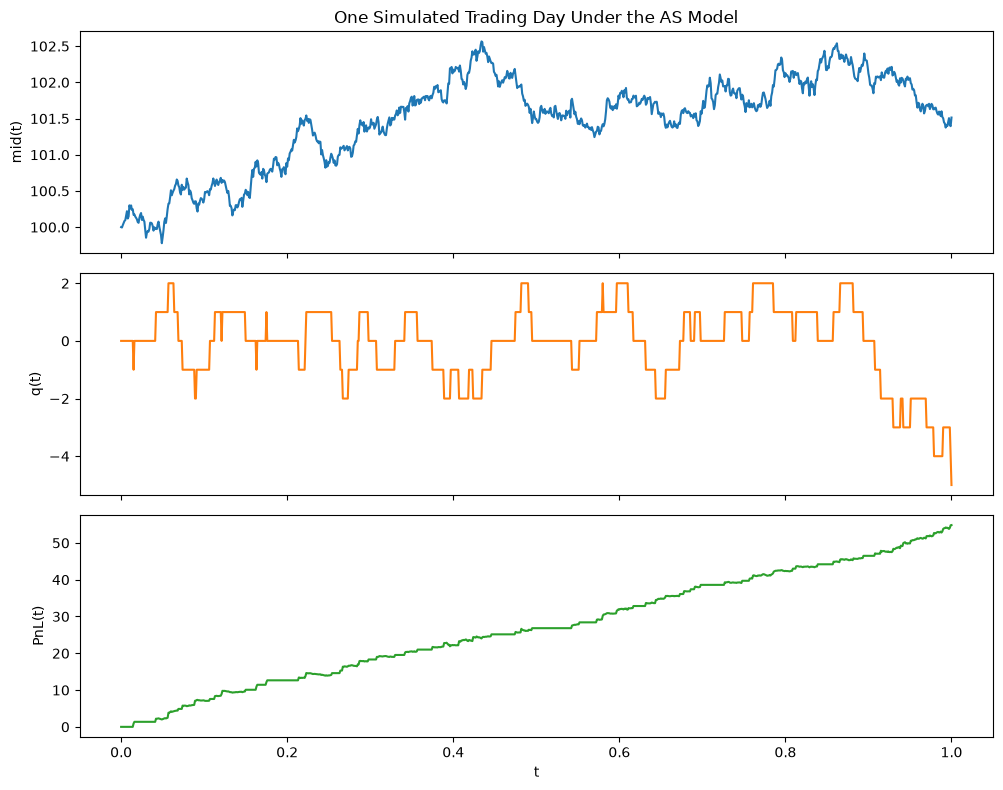

## Average PnL Across Simulated Paths

```python
rng4 = np.random.default_rng(7)
n_paths = 50
pnl_paths = np.empty((n_paths, int(1.0 / 0.001) + 1))
for i in range(n_paths):
    t_i, _, _, pnl_i = simulate_as(rng4)
    pnl_paths[i] = pnl_i

fig, ax = plt.subplots(figsize=(9, 5))
for i in range(n_paths):
    ax.plot(t_i, pnl_paths[i], color="C2", alpha=0.15, lw=1)
ax.plot(t_i, pnl_paths.mean(axis=0), color="black", lw=2, label=f"Average PnL across {n_paths} paths")
ax.axhline(0, color="grey", ls="--", lw=1)
ax.set_xlabel("t")
ax.set_ylabel("PnL(t)")
ax.legend()
plt.tight_layout()
plt.show()

print(f"mean final PnL = {pnl_paths[:, -1].mean():.2f}, std = {pnl_paths[:, -1].std():.2f}")
```

## Average PnL Across Simulated Paths

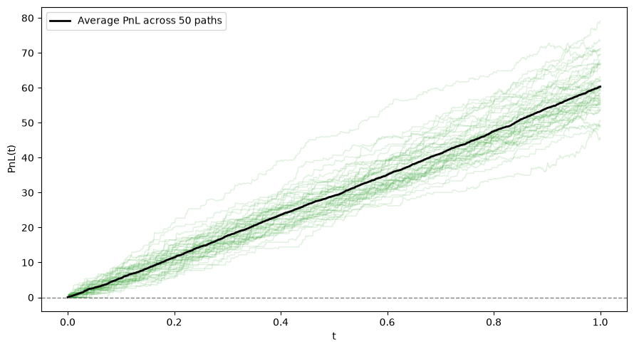

```
mean final PnL = 60.32, std = 6.95
```

## From Simulation to a Real Backtest

The simulation above draws fills from a model. `backtest/` in this module’s folder runs a real market-making strategy against the **real SPY tape** from `data/20260812_spy.txt`, event by event, with a proper fake broker instead of a fill-probability formula:

- **`fake_broker.py`** — parses the tape into two kinds of incoming messages, `QuoteUpdate` (a new best bid/ask) and `TradePrint` (an executed trade), and holds our resting limit orders. On every trade print it checks whether the trade would have crossed one of our orders and, if so, produces an `OrderFilled` message. Zero latency: our orders and cancels take effect instantly, but the broker only ever looks at ticks already read — no peeking ahead.
- **`main.py`** — a plain `for` loop. Each iteration calls one function, `handle_next_tick(broker, book)`, which (a) reads every message the broker produced since the last call and updates our book (best bid/ask, inventory, cash), then (b) cancels our old quotes and sends new ones resting just *behind* the touch — bid below the best bid, ask above the best ask — shifted by inventory, the same skew idea as $r = s - q\gamma\sigma^2\tau$, without the calculus. Resting behind the touch instead of improving it is what lets the strategy earn the spread rather than pay for fill priority. Quotes only rest during regular trading hours, 9:30–4:00; outside that window we just watch the tape.

```
python main.py ../../../data/20260812_spy.txt --plot
```

`--plot` shows mark-to-market PnL over the course of the trading day.

## Reading the Simulation Through Today’s Lens

| Quantity | What it is | Tool from this module |
| --- | --- | --- |
| The venues, priority rules, and fees behind every fill | Institutional plumbing, not randomness | **Market microstructure** (Part 2) |
| Rebates, fees, PFOF, toxicity | Real revenue/cost terms beyond the quoted spread | **Market microstructure** (Part 2) |
| $r, \delta$ (reservation price, half-spread) | Turns raw quoting into an inventory-aware policy | Previewed today; developed fully in CS 3 |

The market maker’s edge isn’t just “the spread” — it’s the spread plus rebates, minus fees and adverse selection, earned within the rules of a fragmented, priority-driven market. Today’s tools let us reason about that institutional layer precisely; CS 3 is where you build the full inventory-aware policy on top of it.

# Part 4: Some Hints on Case Study 3

## Hint 1: Collecting Trade Deltas from the Tape

CS 3 Section 1 asks you to calibrate $k$ and $A$ by relating *how far a trade’s price sits from the prevailing mid* to *how often trades happen there*. Step one is just collecting those distances, $\delta = |\text{trade price} - \text{mid}|$, off the real tape:

```python
import sys
sys.path.append("backtest")
from fake_broker import _parse_line, QuoteUpdate, TradePrint

MAX_MESSAGES = 300_000  # same cap backtest/main.py defaults to, keeps this demo fast

bid = ask = None
deltas = []
first_time = last_time = None
with open("../../data/20260812_spy.txt") as f:
    for i, line in enumerate(f):
        if i >= MAX_MESSAGES:
            break
        msg = _parse_line(line)
        first_time = first_time or msg.time
        last_time = msg.time
        if isinstance(msg, QuoteUpdate):
            bid, ask = msg.bid, msg.ask
        elif isinstance(msg, TradePrint) and bid is not None:
            deltas.append(abs(msg.price - (bid + ask) / 2))

deltas = np.array(deltas)
elapsed_seconds = (last_time - first_time).total_seconds()
print(f"{len(deltas):,} trades over {elapsed_seconds:,.0f} seconds of tape")

fig, ax = plt.subplots(figsize=(8, 4.5))
ax.hist(deltas, bins=60, color="C0")
ax.set_xlabel(r"$\delta$ = |trade price $-$ prevailing midpoint|")
ax.set_ylabel("trade count")
ax.set_title("How Far From the Mid Do Trades Actually Happen?")
plt.tight_layout()
plt.show()
```

- Reuses `_parse_line` from `backtest/fake_broker.py` instead of re-deriving tape parsing — the same parser the real backtest runs on.
- A `QuoteUpdate` tells you the prevailing mid at that instant; the next `TradePrint` is one data point: “a trade happened at distance $\delta$ from the mid.”
- Most trades cluster right at the touch ($\delta$ near zero), thinning out fast as $\delta$ grows — exactly the shape $\lambda(\delta) = Ae^{-k\delta}$ is meant to capture.
- `deltas` and `elapsed_seconds` are what Hint 2 buckets and fits.

## Hint 1: Collecting Trade Deltas from the Tape

```
39,524 trades over 1,392 seconds of tape
```

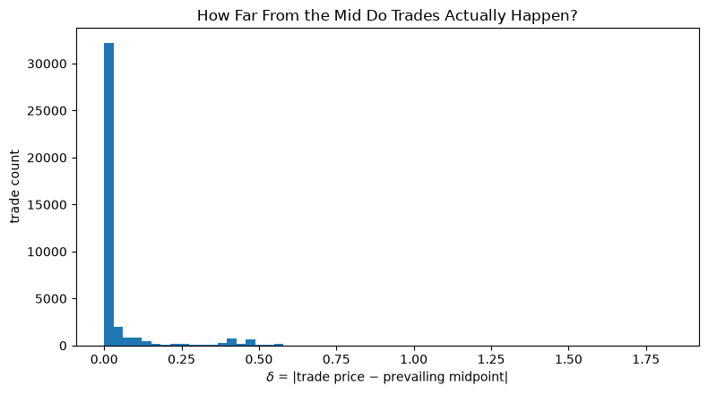

## Hint 2: Estimating $A$ and $k$, Conceptually

The fill-intensity model says trades happen at distance $\delta$ from the mid at rate $\lambda(\delta) = Ae^{-k\delta}$. Taking logs turns this into something you can fit with a straight line:

$$\log \lambda(\delta) = \log A - k\delta$$

**The recipe:**

1. **Bucket** the $\delta$’s from Hint 1 into bins.
2. **Count** trades per bin, divide by the elapsed tape time to get an observed rate $\hat\lambda(\delta)$ per bin (trades per second at that distance).
3. **Fit a line** to $\log \hat\lambda(\delta)$ vs. the bin’s $\delta$ — the slope is $-k$, the intercept is $\log A$.

```python
bins = np.linspace(0, np.quantile(deltas, 0.95), 15)
bin_mids = 0.5 * (bins[:-1] + bins[1:])
counts, _ = np.histogram(deltas, bins=bins)
rate = counts / elapsed_seconds

keep = rate > 0  # log is undefined at zero -- drop empty bins
k_hat, log_A_hat = np.polyfit(bin_mids[keep], np.log(rate[keep]), 1)
k_hat = -k_hat
A_hat = np.exp(log_A_hat)
print(f"k_hat = {k_hat:.2f}, A_hat = {A_hat:.2f}")

fig, ax = plt.subplots(figsize=(8, 4.5))
ax.scatter(bin_mids, np.log(rate), color="C1", label="observed log-intensity")
ax.plot(bin_mids, log_A_hat - k_hat * bin_mids, color="black", label=r"fitted $\log A - k\delta$")
ax.set_xlabel(r"$\delta$")
ax.set_ylabel(r"$\log \hat\lambda(\delta)$")
ax.legend()
plt.tight_layout()
plt.show()
```

- This fits the *market’s* aggregate trade intensity as a function of distance from the mid — you don’t have a history of fills on your own resting orders, so the whole tape’s trade arrivals are the standard stand-in for “how likely is an order resting at distance $\delta$ to get hit.”
- The real tape won’t sit as neatly on the line as the simulator does — bucket counts get noisy once $\delta$ is large and trades there are rare. That’s expected; say so in your prose cell rather than hiding it.
- Once you have $\hat k, \hat A$ (and $\hat\sigma$ from realized volatility), plug them into `simulate_as` and compare against the real `main.py` backtest, per the case study prompt.

## Hint 2: Estimating $A$ and $k$, Conceptually

```
k_hat = 11.70, A_hat = 2.38
```

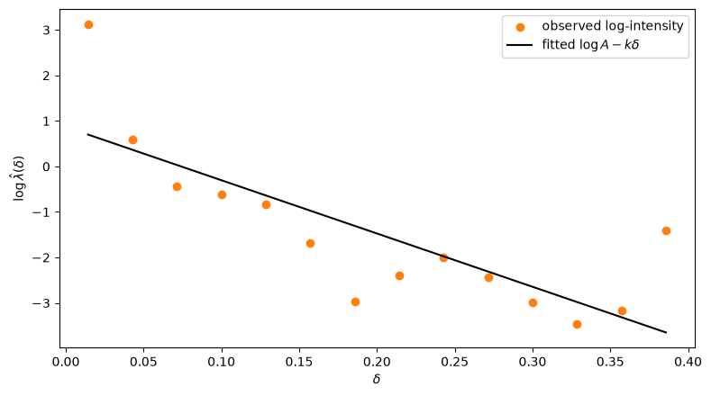

## What We Learned: Module 8 Summary

| Concept | Role |
| --- | --- |
| Fragmentation / Reg NMS | Why “the market” is really 16+ linked venues, not one book |
| Lit exchanges vs. dark pools | Displayed quotes vs. off-exchange internalized/negotiated trades |
| Price-time priority | Within a price level, first-in-first-out; speed buys queue position |
| Market data tiers (L1/L2/L3, MBP/MBO) | How much of the book — down to individual (anonymous) orders — you can actually observe |
| Maker-taker rebates | A real, per-share revenue stream on top of the quoted spread |
| Order flow toxicity / adverse selection | Why not all liquidity-taking flow is equally profitable to fill |
| Payment for order flow | Why much retail flow never reaches a lit exchange at all |
| SIP vs. direct feeds, cross-venue arbitrage | Why a “single” NBBO still has a latency gap between participants |
| Speed-of-light latency floor | Why some latency numbers are physics, not engineering |

## Looking Ahead: Module 9

Next module: **Itô’s lemma** — the calculus rule for transforming functions of Brownian motion, which lets us go from “the stock price has no predictable drift” to pricing derivatives written on it. This is the bridge from CS 3 (market making) to **CS 4: Options Trading**, where the tools from this whole continuous-time unit — Poisson processes, Brownian motion, and now Itô’s lemma — come together in the Black-Scholes derivation.

## References

- Avellaneda, M. & Stoikov, S. (2008). *High-frequency trading in a limit order book*. Quantitative Finance, 8(3), 217–224.
- Baxter, M. & Rennie, A. (1996). *Financial Calculus: An Introduction to Derivative Pricing*. Cambridge University Press.
- Harris, L. (2003). *Trading and Exchanges: Market Microstructure for Practitioners*. Oxford University Press.
- Securities Exchange Act of 1934, §11A (added by the Securities Acts Amendments of 1975), 15 U.S.C. §78k-1.
- U.S. Securities and Exchange Commission. *Regulation NMS*, 17 CFR Part 242; adopting release No. 34-51808 (June 9, 2005), 70 FR 37496.